# Nuclear Energy in the Global Power Mix

Akima M. Terrones

2025-11-11

## Introduction

Nuclear energy is an important source of low-carbon electricity, playing a role in helping countries meet rising energy needs while reducing greenhouse-gas emissions. However, nuclear energy adoption has not been the worldwide 1st approach to energy. Some countries have expanded nuclear energy production, while others have reduced output or phased out facilities, especially after major events such as its use in weaponry and power plant accidents.

This project examines historical nuclear electricity production across countries to identify long-term trends, compare major producers, and understand how global patterns may reflect policy, safety, and environmental considerations. This analysis aims to provide insight into nuclear energy’s place in today’s energy landscape and its potential role in the future.

## About the Dataset

The dataset used in this project comes from **Our World in Data**, an open-access research platform that compiles global historical information about energy, climate, and development. The file includes country-level observations of nuclear electricity production over time.

Key variables include:

- **country** — Name of the country or region
- **code** — Standard three-letter country code
- **year** — Year of measurement
- **nuclear_TWh** — Electricity produced from nuclear power (terawatt-hours)

The data spans multiple countries and years, allowing us to observe long-term nuclear energy trends globally. It allows comparisons across countries and time. This dataset is useful for exploring how nuclear power has changed, which nations produce the most, and how external events or policy changes may have influenced energy production.

## Data observations and Visualizations

#### Which countries have had the highest nuclear energy production over time, and how have their outputs changed?

The dataset identifies the highest total nuclear electricity producers as the United States, France, Japan, Russia, and Germany, with an additional aggregated series labeled “World”, which represents global nuclear production as a whole.

Among these, the United States has consistently led in nuclear electricity generation, maintaining a significant lead over other countries throughout the observed period, reflecting its early investment in nuclear technology and its large reactor fleet. France also shows sustained high output due to it’s long-standing national strategy to generate most of its electricity from nuclear power.

Japan and Germany show noticeable declines after 2011. Japan’s sharp drop corresponds with the shutdown of many reactors following the Fukushima Daiichi accident, while Germany’s decline reflects its commitment to phasing out nuclear energy entirely. Russia displays a steadier long-term trend, maintaining moderate but consistent levels of nuclear production.

```
## [1] "World"         "United States" "France"        "Japan"
## [5] "Russia"        "Germany"
```

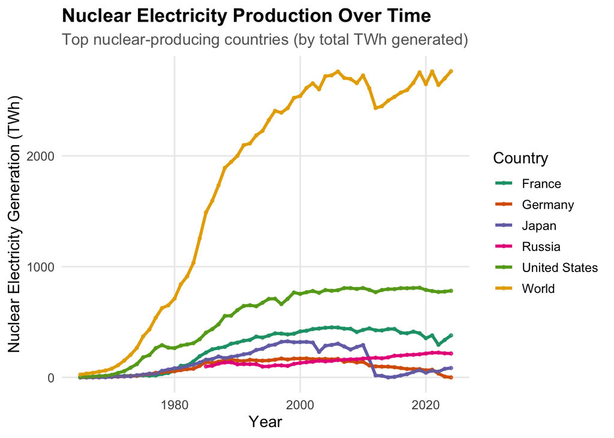

Overall, these patterns highlight how national energy policies, safety events, and global responses to nuclear risks have shaped long-term nuclear energy production. Countries that view nuclear power as a strategic energy source maintain stable or increasing output, while others have reduced production in response to public safety concerns and policy shifts.

#### How has global nuclear electricity generation changed over time?

[figure not shown]